> **Tip**: Welcome to the Investigate a Dataset project! You will find tips in quoted sections like this to help organize your approach to your investigation. Before submitting your project, it will be a good idea to go back through your report and remove these sections to make the presentation of your work as tidy as possible. First things first, you might want to double-click this Markdown cell and change the title so that it reflects your dataset and investigation.

# Project: Investigate 2019 startup business related statistics

- Introduction
- Data Wrangling
- Exploratory Data Analysis
- Conclusions

## Introduction

> **Tip**: from gap minder datasets, other datasets, private sector and trading, business environment, I have chosen the "Ease of doing business index ( 1 = most business friendly regulations)", "Business extent of disclosure index (0=less disclosure to 10=more disclosure)" and "cost of business startup precedures (% of GNI per capita)".

**Explanation of the data**:

> First: Ease of doing business index ( 1 = most business friendly regulations), it means that Ease of doing business ranks economies from 1 to 190, with first place being the best. A high ranking (a low numerical rank) means that the regulatory environment is conducive to business operation. source: https://www.indexmundi.com/facts/japan/indicator/IC.BUS.EASE.XQ#:~:text=Japan%20-%20Ease%20of%20doing%20business%20index%20%281%3Dmost,the%20regulatory%20environment%20is%20conducive%20to%20business%20operation.

> Second: Cost of business startup precedures (% of GNI per capita), it means costs to register a business which is normalized by presenting it as a percentage of gross national income (GNI) per capita. source: https://www.indexmundi.com/facts/indicators/IC.REG.COST.PC.ZS#:~:text=Cost%20of%20business%20start-up%20procedures%20%28%25%20of%20GNI,%28%25%20of%20GNI%20per%20capita%29%20varies%20by%20country.

> Third: Business extent of disclosure index (0=less disclosure to 10=more disclosure), it means that Disclosure index measures the extent to which investors are protected through disclosure of ownership and financial information. The index ranges from 0 to 10, with higher values indicating more disclosure. source:https://www.indexmundi.com/facts/indicators/IC.BUS.DISC.XQ#:~:text=Business%20extent%20of%20disclosure%20index%20%280%3Dless%20disclosure%20to,to%2010%2C%20with%20higher%20values%20indicating%20more%20disclosure.

> **The analysis process:** (What to expect !) Fist thing was to preapre just one clean file to explore it, so cleaning and wrangling the data was criucial, especially that one of the datases is available for 2019 only. Since, we have understood the meaning of the data, it is clear that the questions are related to the countries with the best easiness of doing the business as this what enterpreneurs look for, keeping mind that this is not the only factor that will make the enterpreneur take the final decision to start or to do business in a certain country, as cost is crucial. Never to ignore the investors who will help the business start and grow, those who care about the extent of disclosure, to make sure that their financial information is protected. Usually the Enterpreneur will kepp that in mind while deciding which country/ countries is the most suitable. that´s why the first step, after cleaning the data, was to explore and visulaise relationships between individual variable and multiple ones too.

> Here, I decided which of the questions based on the data that could help in the decision making process effectively.

> So, to help in the decision making, i prefered to attach the cost of business startup procedures, as it is crucial in decision making, let´s say a certain country is the most friendly but when it comes to the precedures cost, it is very high, then the decision to choose this country would be hard. That´s how i concluded that it is important to know if there´s a relationship between the cost of procedures and easiness of doing a business and especially if it is a good relationship for the enterpreneur, that´s how i came up with the first question to help in decision making. **First question: Are the countires with high easiness index have low precedures cost?**

> Then after i found the relationship, and if it is really good for the enterpreneur, it will be helpful to simply identify the top countries with such traits, and check their disclosure index from 1 to ten, to help in more precise decision makinig process. Hence, the most important second question to ask is **Second question:Identify top 5 countires with lowest cost precedures, and top 5 countires with with highest ease of doing business procedures? then the top in both together with mentioning their disclosure index?**

> Answering these questions will be helpful for those thinking about starting an international business and trying to identify patterns to choose where they could start depending on those indicators as a first step in directing their search.

> the dependent variable is the countries and the three independents are the cost of business, ease of business, and extent of disclosure. Finally, I will draw conlsuion and insights based on the outcome.

Let´s import packages that i plan to use in this project. and use the magic "%" to view the graphs in this notebook.

```python
import pandas as pd
import numpy as np
import matplotlib.pyplot as plt
import seaborn as sns
from pandas.api.types import is_numeric_dtype
%matplotlib inline
```

## Data Wrangling

> **Tip**: In this section of the report, you will load in the data, check for cleanliness, and then trim and clean your dataset for analysis. Make sure that you document your steps carefully and justify your cleaning decisions.

### General Properties

```python
df_ease = pd.read_csv('ic_bus_ease_xq.csv')
df_cost = pd.read_csv('ic_reg_cost_pc_zs.csv')
df_disclosure = pd.read_csv('ic_bus_disc_xq.csv')
```

Loading the files that contain the data we need.

**First file** contains information about "Ease of doing business index ( 1 = most business friendly regulations)", that will be refered to as "df_ease".

**Second file** contains information about " Cost of business startup precedures (% of GNI per capita)", that will be refered to as "df_cost".

**Third file** contains information about "Business extent of disclosure index (0=less disclosure to 10=more disclosure)", that will be refered to as "df_disclosure".

then, reviewing each file content.

```python
df_ease.head(1)
```

|  | country | 2019 |
| --- | --- | --- |
| 0 | Afghanistan | 173 |

```python
df_cost.head(1)
```

|  | country | 2003 | 2004 | 2005 | 2006 | 2007 | 2008 | 2009 | 2010 | 2011 | 2012 | 2013 | 2014 | 2015 | 2016 | 2017 | 2018 | 2019 |
| --- | --- | --- | --- | --- | --- | --- | --- | --- | --- | --- | --- | --- | --- | --- | --- | --- | --- | --- |
| 0 | Afghanistan | NaN | 72.0 | 75.2 | 67.4 | 84.6 | 59.5 | 30.2 | 26.7 | 25.8 | 22.5 | 14.4 | 15.1 | 19.0 | 19.9 | 82.3 | 6.4 | 6.8 |

```python
df_disclosure.head(1)
```

|  | country | 2005 | 2006 | 2007 | 2008 | 2009 | 2010 | 2011 | 2012 | 2013 | 2014 | 2015 | 2016 | 2017 | 2018 | 2019 |
| --- | --- | --- | --- | --- | --- | --- | --- | --- | --- | --- | --- | --- | --- | --- | --- | --- |
| 0 | Afghanistan | 1.0 | 1.0 | 1.0 | 1.0 | 1.0 | 1.0 | 1.0 | 1.0 | 1.0 | 1.0 | 1.0 | 1.0 | 1.0 | 8.0 | 8.0 |

After reviewing the data Then it´s time to understand it to be able to clean it later.

First, let´s understand it is columns, rows, dtype, non-null count.

```python
df_ease.info()
```

```
<class 'pandas.core.frame.DataFrame'>
RangeIndex: 189 entries, 0 to 188
Data columns (total 2 columns):
 #   Column   Non-Null Count  Dtype
---  ------   --------------  -----
 0   country  189 non-null    object
 1   2019     189 non-null    int64
dtypes: int64(1), object(1)
memory usage: 3.1+ KB
```

```python
df_cost.info()
```

```
<class 'pandas.core.frame.DataFrame'>
RangeIndex: 190 entries, 0 to 189
Data columns (total 18 columns):
 #   Column   Non-Null Count  Dtype
---  ------   --------------  -----
 0   country  190 non-null    object
 1   2003     133 non-null    float64
 2   2004     143 non-null    float64
 3   2005     162 non-null    float64
 4   2006     166 non-null    float64
 5   2007     169 non-null    float64
 6   2008     170 non-null    float64
 7   2009     171 non-null    float64
 8   2010     171 non-null    float64
 9   2011     173 non-null    float64
 10  2012     177 non-null    float64
 11  2013     188 non-null    float64
 12  2014     188 non-null    float64
 13  2015     189 non-null    float64
 14  2016     189 non-null    float64
 15  2017     189 non-null    float64
 16  2018     190 non-null    float64
 17  2019     190 non-null    float64
dtypes: float64(17), object(1)
memory usage: 26.8+ KB
```

```python
df_disclosure.info()
```

```
<class 'pandas.core.frame.DataFrame'>
RangeIndex: 190 entries, 0 to 189
Data columns (total 16 columns):
 #   Column   Non-Null Count  Dtype
---  ------   --------------  -----
 0   country  190 non-null    object
 1   2005     189 non-null    float64
 2   2006     189 non-null    float64
 3   2007     189 non-null    float64
 4   2008     189 non-null    float64
 5   2009     189 non-null    float64
 6   2010     189 non-null    float64
 7   2011     189 non-null    float64
 8   2012     189 non-null    float64
 9   2013     189 non-null    float64
 10  2014     189 non-null    float64
 11  2015     189 non-null    float64
 12  2016     189 non-null    float64
 13  2017     189 non-null    float64
 14  2018     190 non-null    float64
 15  2019     190 non-null    float64
dtypes: float64(15), object(1)
memory usage: 23.9+ KB
```

Second, each file data´s shape to know if i can merge them easily later.

```python
df_ease.shape
```

```
(189, 2)
```

```python
df_cost.shape
```

```
(190, 18)
```

```python
df_disclosure.shape
```

```
(190, 16)
```

Finally, let´s comprehend the data values in details

```python
df_ease.describe()
```

|  | 2019 |
| --- | --- |
| count | 189.000000 |
| mean | 95.925926 |
| std | 54.823361 |
| min | 1.000000 |
| 25% | 49.000000 |
| 50% | 96.000000 |
| 75% | 143.000000 |
| max | 190.000000 |

```python
df_cost.describe()
```

|  | 2003 | 2004 | 2005 | 2006 | 2007 | 2008 | 2009 | 2010 | 2011 | 2012 | 2013 | 2014 | 2015 | 2016 | 2017 | 2018 | 2019 |
| --- | --- | --- | --- | --- | --- | --- | --- | --- | --- | --- | --- | --- | --- | --- | --- | --- | --- |
| count | 133.000000 | 143.000000 | 162.000000 | 166.000000 | 169.000000 | 170.000000 | 171.000000 | 171.000000 | 173.000000 | 177.000000 | 188.000000 | 188.000000 | 189.000000 | 189.000000 | 189.000000 | 190.000000 | 190.000000 |
| mean | 105.638346 | 94.276224 | 85.119136 | 80.906024 | 71.554438 | 57.174706 | 47.420468 | 45.536257 | 40.395376 | 35.961017 | 33.001596 | 29.022872 | 28.283069 | 27.118519 | 26.573545 | 24.117895 | 19.868947 |
| std | 232.550260 | 193.407193 | 153.275439 | 157.328950 | 142.091679 | 105.260197 | 86.748769 | 76.883512 | 65.181678 | 51.846643 | 51.118293 | 43.264755 | 45.001480 | 47.208643 | 46.886533 | 44.227176 | 33.793070 |
| min | 0.000000 | 0.000000 | 0.000000 | 0.000000 | 0.000000 | 0.000000 | 0.000000 | 0.000000 | 0.000000 | 0.000000 | 0.000000 | 0.000000 | 0.000000 | 0.000000 | 0.000000 | 0.000000 | 0.000000 |
| 25% | 11.900000 | 11.400000 | 11.550000 | 9.300000 | 8.300000 | 5.925000 | 5.150000 | 5.200000 | 4.700000 | 4.100000 | 3.800000 | 3.300000 | 3.300000 | 2.800000 | 2.300000 | 2.200000 | 2.125000 |
| 50% | 28.000000 | 26.600000 | 28.750000 | 25.250000 | 21.800000 | 18.700000 | 16.300000 | 17.500000 | 16.400000 | 14.900000 | 13.300000 | 12.950000 | 12.200000 | 12.200000 | 10.400000 | 8.850000 | 7.750000 |
| 75% | 112.000000 | 108.500000 | 106.550000 | 93.825000 | 74.700000 | 64.650000 | 53.550000 | 52.100000 | 47.700000 | 46.800000 | 42.150000 | 33.850000 | 33.000000 | 31.200000 | 29.200000 | 24.775000 | 22.125000 |
| max | 1540.000000 | 1490.000000 | 1190.000000 | 1310.000000 | 1180.000000 | 935.000000 | 848.000000 | 735.000000 | 551.000000 | 287.000000 | 372.000000 | 247.000000 | 330.000000 | 422.000000 | 352.000000 | 393.000000 | 212.000000 |

```python
df_disclosure.describe()
```

|  | 2005 | 2006 | 2007 | 2008 | 2009 | 2010 | 2011 | 2012 | 2013 | 2014 | 2015 | 2016 | 2017 | 2018 | 2019 |
| --- | --- | --- | --- | --- | --- | --- | --- | --- | --- | --- | --- | --- | --- | --- | --- |
| count | 189.000000 | 189.000000 | 189.000000 | 189.000000 | 189.000000 | 189.000000 | 189.000000 | 189.000000 | 189.000000 | 189.000000 | 189.000000 | 189.000000 | 189.000000 | 190.000000 | 190.000000 |
| mean | 4.615873 | 4.658201 | 4.716402 | 4.801058 | 4.917460 | 4.970370 | 5.060317 | 5.166138 | 5.245503 | 5.435979 | 5.531217 | 5.594709 | 5.647619 | 5.723158 | 5.812632 |
| std | 2.510481 | 2.529275 | 2.524939 | 2.494973 | 2.454341 | 2.464206 | 2.496884 | 2.435927 | 2.436828 | 2.509382 | 2.518470 | 2.533724 | 2.535379 | 2.552515 | 2.559648 |
| min | 0.000000 | 0.000000 | 0.000000 | 0.000000 | 0.000000 | 0.000000 | 0.000000 | 0.000000 | 0.000000 | 0.000000 | 0.000000 | 0.000000 | 0.000000 | 0.000000 | 0.000000 |
| 25% | 3.000000 | 3.000000 | 3.000000 | 3.000000 | 3.000000 | 3.000000 | 3.000000 | 3.000000 | 4.000000 | 4.000000 | 4.000000 | 4.000000 | 4.000000 | 4.000000 | 4.000000 |
| 50% | 4.000000 | 4.000000 | 5.000000 | 5.000000 | 5.000000 | 5.000000 | 5.000000 | 5.000000 | 6.000000 | 6.000000 | 6.000000 | 6.000000 | 6.000000 | 6.000000 | 6.000000 |
| 75% | 6.000000 | 6.000000 | 6.000000 | 6.000000 | 6.000000 | 7.000000 | 7.000000 | 7.000000 | 7.000000 | 7.000000 | 7.000000 | 7.000000 | 7.000000 | 7.850000 | 8.000000 |
| max | 10.000000 | 10.000000 | 10.000000 | 10.000000 | 10.000000 | 10.000000 | 10.000000 | 10.000000 | 10.000000 | 10.000000 | 10.000000 | 10.000000 | 10.000000 | 10.000000 | 10.000000 |

### Cleaning the data

> **next step**: after we have understood the data from the previous functions, it is time to clean our data:

> The ease data, i will check for NaN values, duplicates and rename the column of the precentage to ease indicator.

> The diclosure data, i will check for NaN values, duplicates, then drop all columns except 2019 only and rename it as disclosure_ind

> Hence, I wll check the datatype to be able to merge the datasets into one edited combined dataset

> Finally, i will add the regions column to help answer the questions posed above, and to start the exploration.

**Cleaning the firs file**

```python
df_ease.isnull().sum()
```

```
country    0
2019       0
dtype: int64
```

It is clear form the info we have seen above, anyway since it is zero, so there´s no null.

```python
sum(df_ease.duplicated())
```

```
0
```

Since it is Zero, so there´s no duplicates-

```python
df_ease.rename(columns = {'2019':'ease_ind'}, inplace=True)
df_ease.head(1)
```

|  | country | ease_ind |
| --- | --- | --- |
| 0 | Afghanistan | 173 |

Renamed the column from 2019 to represent the values it has which are the ease of doing business indicators, that´s why i renamed "ease_ind".

So when we added to the final table it will be ready.

```python
df_cost.isnull().sum()
```

```
country     0
2003       57
2004       47
2005       28
2006       24
2007       21
2008       20
2009       19
2010       19
2011       17
2012       13
2013        2
2014        2
2015        1
2016        1
2017        1
2018        0
2019        0
dtype: int64
```

There´s a lot of mising values, but i will not do anything about it.

Becasue the columns we are interested in are the country and 2019., and both has zero NaN.

```python
sum(df_cost.duplicated())
```

```
0
```

Since it is Zero, so there´s no duplicates-

```python
#dropping all the columns except country and 2019
df_cost.drop(df_cost.columns.difference(['country','2019']), 1, inplace= True)
df_cost.head(5)
```

|  | country | 2019 |
| --- | --- | --- |
| 0 | Afghanistan | 6.8 |
| 1 | Angola | 11.1 |
| 2 | Albania | 10.8 |
| 3 | United Arab Emirates | 17.2 |
| 4 | Argentina | 5.0 |

Here, I have droped all not needed columns, to keep the ones we want only. Which are the country and the year 2019

```python
df_cost.rename(columns = {'2019':'cost_ind'}, inplace=True)
df_cost.head(1)
```

|  | country | cost_ind |
| --- | --- | --- |
| 0 | Afghanistan | 6.8 |

Renamed the column from 2019 to represent the values it has which are the cost of precedures to startup business indicators, that´s why i renamed "cost_ind".

So when we added to the final table it will be ready.

```python
df_disclosure.isnull().sum()
```

```
country    0
2005       1
2006       1
2007       1
2008       1
2009       1
2010       1
2011       1
2012       1
2013       1
2014       1
2015       1
2016       1
2017       1
2018       0
2019       0
dtype: int64
```

There´s a lot of mising values, but i will not do anything about it.

Becasue the columns we are interested in are the country and 2019., and both has zero NaN.

```python
sum(df_disclosure.duplicated())
```

```
0
```

Since it is Zero, so there´s no duplicates-

```python
df_disclosure.drop(df_disclosure.columns.difference(['country','2019']), 1, inplace= True)
df_disclosure.head()
```

|  | country | 2019 |
| --- | --- | --- |
| 0 | Afghanistan | 8.0 |
| 1 | Angola | 4.0 |
| 2 | Albania | 9.0 |
| 3 | United Arab Emirates | 10.0 |
| 4 | Argentina | 7.0 |

Here, I have droped all not needed columns, to keep the ones we want only. Which are the country and the year 2019

```python
df_disclosure.rename(columns = {'2019':'disclosure_ind'}, inplace=True)
df_disclosure.head(1)
```

|  | country | disclosure_ind |
| --- | --- | --- |
| 0 | Afghanistan | 8.0 |

Renamed the column from 2019 to represent the values it has which are the entent of disclosure indicators, that´s why i renamed "disclosure_ind".

So when we added to the final table it will be ready.

```python
df_combined = df_ease.merge(df_cost, left_on ='country', right_on='country', how="outer")
```

Time to merge them!

we started with merging the first two tables into one table as this one shown below!

```python
df_combined.head(1)
```

|  | country | ease_ind | cost_ind |
| --- | --- | --- | --- |
| 0 | Afghanistan | 173.0 | 6.8 |

It is time to add the third table with the same way!

```python
df_combined_2 = df_combined.merge(df_disclosure, left_on ='country', right_on='country', how="outer")
df_combined_2.head(1)
```

|  | country | ease_ind | cost_ind | disclosure_ind |
| --- | --- | --- | --- | --- |
| 0 | Afghanistan | 173.0 | 6.8 | 8.0 |

The final dataset, we wanto is ready. But it needs some shaping, as one of the tables was 189 rows only while the other two are 190, that was clear when we use ".shape", to know the data better!.

So let´s check for NaNs.

```python
df_combined_2.isnull().sum()
```

```
country           0
ease_ind          1
cost_ind          0
disclosure_ind    0
dtype: int64
```

"ease_ind" has a missing value, that can be droped or filled! For the sake of not losing one of the listed countries, it is better to fill it.

Since it is an index value that represent a certain score from 1 to 190, it is better to get the mean and fill the missing value with the mean of the column.

As the other ways will be randomly giving a number that´s not related at all, as this value is not related with the other values, so it is better to get the average value of the column and fill it with it.

```python
mean = df_combined_2['ease_ind'].mean()
mean
```

```
95.92592592592592
```

```python
df_combined_2['ease_ind'] = df_combined_2['ease_ind'].fillna(mean)
```

The missing value is filled with the mean, to prove that let´s check for NaNs once more.

```python
df_combined_2.isnull().sum()
```

```
country           0
ease_ind          0
cost_ind          0
disclosure_ind    0
dtype: int64
```

Now, we are sure that There´s no NaNs.

Since we know form the above -info for each that the datatypes has no problem with, that´s why the tables were merged successfully and there´s no duplication.

It is time to save the new dataset.

```python
df_combined_2.to_csv('business statistics.csv', index=False)
```

## Exploratory Data Analysis

> **Tip**: Now that you've trimmed and cleaned your data, you're ready to move on to exploration. Compute statistics and create visualizations with the goal of addressing the research questions that you posed in the Introduction section. It is recommended that you be systematic with your approach. Look at one variable at a time, and then follow it up by looking at relationships between variables.

### Visualize and explore data

At first we will load the edited file to start manipulating the data.

```python
df = pd.read_csv('business statistics.csv')
```

```python
df.head(1)
```

|  | country | ease_ind | cost_ind | disclosure_ind |
| --- | --- | --- | --- | --- |
| 0 | Afghanistan | 173.0 | 6.8 | 8.0 |

To decipt the distributio of the continous features of each numerical values´ columns in the dataset, here´s histogram for each column.

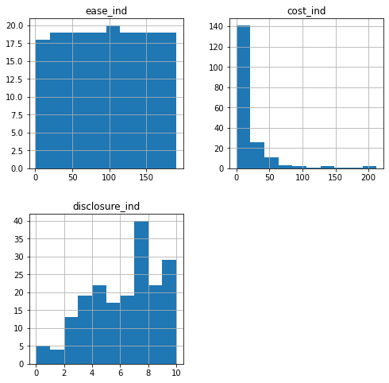

```python
df.hist(figsize = (8, 8));
```

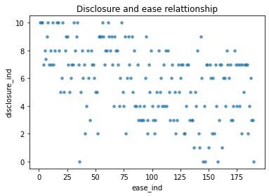

```python
plot_1 = df.plot(x='ease_ind', y='disclosure_ind', kind='scatter', s= 12, alpha= 0.7);
plt.title("Disclosure and ease relattionship");
```

the relations is weak or negative, which indicates that whether thte country´s procedures are easy or not, this doesn´t affect the disclosure strongly.

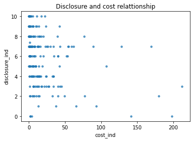

```python
df.plot(x='cost_ind', y='disclosure_ind', kind='scatter', s= 12, alpha= 0.7);
plt.title("Disclosure and cost relattionship");
```

the distribution is normal, which mean there´s no impact between cost and disclosure.

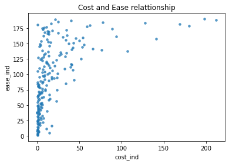

```python
df.plot(x='cost_ind', y='ease_ind', kind='scatter', s= 12, alpha= 0.7);
plt.title("Cost and Ease relattionship");
```

It seems like thers´s strong or postive relationship between the cost indicator and the ease indicator. which mean they have impact on each other

Since we have visualised and explored the data, now it is clear, how i would approach the questions to draw conclusions. I will focus on the relationship between cost adn ease, as it will help us answer the first question. While in the second question we will show the values of disclosure regardless its relations with other variable as it won´t be useful.

### Research Question 1: is the countires with high ease index has low precedures cost?

It is already explained in the introduction how important this question. As it will help us highlight the relationshiop and make decision making process much easier.

```python
ease_median = df['ease_ind'].median()
high = df.query('ease_ind < {}'.format(ease_median))
low = df.query('ease_ind >= {}'.format(ease_median))

mean_cost_high = high['cost_ind'].mean()
mean_cost_low = low['cost_ind'].mean()
```

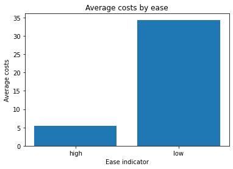

```python
locations = [1, 2]
heights = [mean_cost_high, mean_cost_low]
labels = ['high', 'low']
plt.bar(locations, heights, tick_label=labels)
plt.title('Average costs by ease')
plt.xlabel('Ease indicator')
plt.ylabel('Average costs')
```

using query to get the mean of high and low values of cost in relation to the ease.

I simply got the median/middle value in the values of ease. And made sure that whatevr is less than that median (closer to 1 which is the most friendly) is considered high ease index, while what is greater than the median is low ease index.

The mean of cost indicator in relative to high is calculated then the mean of cost in relative to low ease index also calculated, to be used in the graph to be able to compare between high and low according to the average cost.

As shown above, the graph indicates that countries with high ease indicators are much lesser in cost with 30! It means that high countries that are most friendly to do your business, have lower average costs of nearly 5, unlike low which has about 35 average cost.

So the answer is **yes**, the countires with high ease index has low precedures cost. It is time to find this countries to make the decision.

### Research Question 2 Identify top 5 countires with lowest cost precedures, and top 5 countires with with highest ease of doing business procedures? then the top in both together with mentioning their disclosure index?

In the first question, we got the numbers, here in this question now we have to get the answer to the enterpreneur confusion to make the decision, which is the name of the countries with preferables features, that we have decided on from the previous analysis.

the first preferable feature is the lowest ease_ind, which in fact the coutries with lower ease_ind, that is closer to 1. Here, we will get the top five countries for it.

the second preferable feature is the lowest cost_ind, which is the lower the cost the better for the enterpreneur.

the third preferable feature is the disclosure, which is the closer to 10 the better, as it means higher extent of disclosure.

```python
def visualise_it (df):
    z = df.plot(x='country', kind='bar');
    print(z)
```

Since the following data is all about the data, so i prefered to have a function to visualise it as bar chart, so the user could decide which country to choose just by looking at the bar chart.

```
AxesSubplot(0.125,0.125;0.775x0.755)
```

|  | country | ease_ind | cost_ind | disclosure_ind |
| --- | --- | --- | --- | --- |
| 129 | New Zealand | 1.0 | 0.2 | 10.0 |
| 149 | Singapore | 2.0 | 0.4 | 10.0 |
| 70 | Hong Kong, China | 3.0 | 0.5 | 10.0 |
| 45 | Denmark | 4.0 | 0.2 | 7.0 |
| 92 | South Korea | 5.0 | 14.6 | 8.0 |

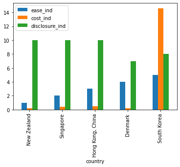

```python
top_5_ease =  df.sort_values(by= ['ease_ind'])[:5]
visualise_it (top_5_ease)
top_5_ease
```

I have sorted the data in ascending order according to the ease_ind and get the top five rows that represent this information.

As we have said that the closer to 1 is the preferable value.

So the top five countries according to ease_ind is the ones mentioned above. This way is more informative, as if the enterpreneur prefere the countries with ease index and want to ignore the other features, the answer is presented here, and even include the other features value according to his preference.

And this is the answer for the first part of the question above.

The output here is more readable as it is the table and the bar chart next to it, so it is easier to spot and compare between the five countries and analyse it quickly, and not just depend the sorting of it.

Here, i easily say New zealand is the one with best ease_ind and from the lowest cost in the data above. whther by comparing the numbers from the table. Or easily analyse the bar chart.

Remember that, both ease and cost indicators are better less, while disclosure the higher the better.

Analysing the chart: i know that i want the lowest value in ease_ind which is New Zealand, then i will check the cost and find that both New Zealand and denmark has lowest cost, finally i will check the disclosure and the first three countries are the highest, from comparing the data.

we conclude that New Zealand is the best option from the five top considering all the features.

```
AxesSubplot(0.125,0.125;0.775x0.755)
```

|  | country | ease_ind | cost_ind | disclosure_ind |
| --- | --- | --- | --- | --- |
| 145 | Rwanda | 38.0 | 0.0 | 8.0 |
| 59 | United Kingdom | 8.0 | 0.0 | 10.0 |
| 160 | Slovenia | 37.0 | 0.0 | 5.0 |
| 77 | Ireland | 24.0 | 0.1 | 9.0 |
| 186 | South Africa | 84.0 | 0.2 | 8.0 |

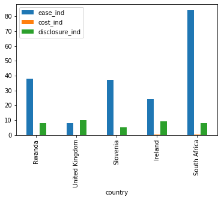

```python
top_5_cost =  df.sort_values(by= ['cost_ind'])[:5]
visualise_it (top_5_cost)
top_5_cost
```

Same as the above, i have sorted the data in an ascending order according to the cost_ind and get the top five rows that represent this information.

As we have said that the less the cost the better, so the less is the preferable value.

The answer to the second part of the question is here, which is the first five countries mentioned above.

From the table, i can tell that Rwanda is the one with the least cost, as it is the first. But from the chart, i can tell that the best option is United kingdom as it has no cost just as rwanda but it is the best in ease_ind as it has also the lowest ease_ind, in addition to the higher disclosure which is even better.

So, the best option here is United Kingdom.

```
AxesSubplot(0.125,0.125;0.775x0.755)
```

|  | country | ease_ind | cost_ind | disclosure_ind |
| --- | --- | --- | --- | --- |
| 59 | United Kingdom | 8.0 | 0.0 | 10.0 |
| 160 | Slovenia | 37.0 | 0.0 | 5.0 |
| 145 | Rwanda | 38.0 | 0.0 | 8.0 |
| 77 | Ireland | 24.0 | 0.1 | 9.0 |
| 129 | New Zealand | 1.0 | 0.2 | 10.0 |

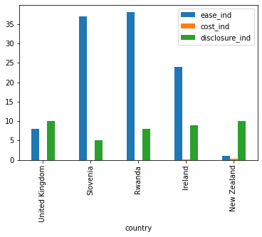

```python
top_5_both_cost =  df.sort_values(by= ['cost_ind', 'ease_ind'])[:5]
visualise_it (top_5_both_cost)
top_5_both_cost
```

wait if you compare this one and the next together as they both has the same goal, which is to sort by both but..

Both has different output because one is prioritrizing the cost which mean that first sort the cost_ind with lowest then the lowest ease_ind associated to it. As the UK adn Slovania both has zero cost_ind but UK first as it has the lower ease_ind.

So, from the cost, the best options is the first three countries, but considering the ease_ind and disclosure_ind, the best option is united kingdom.

```
AxesSubplot(0.125,0.125;0.775x0.755)
```

|  | country | ease_ind | cost_ind | disclosure_ind |
| --- | --- | --- | --- | --- |
| 129 | New Zealand | 1.0 | 0.2 | 10.0 |
| 149 | Singapore | 2.0 | 0.4 | 10.0 |
| 70 | Hong Kong, China | 3.0 | 0.5 | 10.0 |
| 45 | Denmark | 4.0 | 0.2 | 7.0 |
| 92 | South Korea | 5.0 | 14.6 | 8.0 |

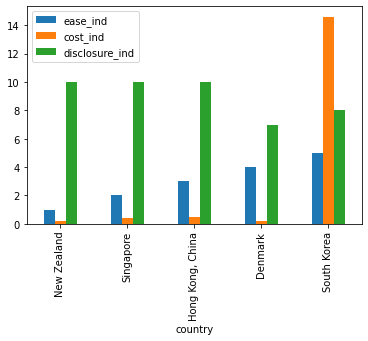

```python
top_5_both_ease =  df.sort_values(by= ['ease_ind', 'cost_ind'])[:5]
visualise_it (top_5_both_ease)
top_5_both_ease
```

Both of them has the same target but give different values. It is because of sort_values and other builtin functions as nsmallest, the functions tend to sort or get the smallest based on the first mentioned column and then the second mentioned one.

So, it depends on the priority you want! Simply, is the cost the most important feature to decide then the ease or vice versa?

Here the best option here is New Zealand as it the lowest cost_ind and ease_ind yet from the highest in disclosure_ind.

## Conclusions

> **Tip**: Finally, summarize your findings and the results that have been performed. Make sure that you are clear with regards to the limitations of your exploration. If you haven't done any statistical tests, do not imply any statistical conclusions. And make sure you avoid implying causation from correlation!

> **Tip**: Once you are satisfied with your work, you should save a copy of the report in HTML or PDF form via the **File** > **Download as** submenu. Before exporting your report, check over it to make sure that the flow of the report is complete. You should probably remove all of the "Tip" quotes like this one so that the presentation is as tidy as possible. Congratulations!

**During data exploration**, i started with visualising and exploring the data to find relationship between it and patterns. that´s how i found out about the realtionship between cost_ind and ease_ind, yet the weak relationship between disclosure_ind and the ease_ind, and that there´s no relationship between it and cost_ind.

**Answering questions:**

> **answering second question** While using the sort_values to answer the second question, i tend to analyse the top five in each feature to point out the best option.

> > In the top five countries according to **ease_ind**, It was interesting to find out that "New Zealand" is the best option to start a business there, as it has least ease_ind, lower cost and highest disclosure_ind.

> > In the top five countries according to **cost_ind**, The best option is "United Kingdom" as it has the lowest ease_ind and zero cost_ind yet the highest in disclosure_ind.

> > In the top five countries according to **both**, i found out that it differs sepending on prioritrizing which column, anyway, it was clear that by prioritrizing ease_ind, it is new Zealan which is the same as we concluded by analysing the chart, as well as, by prioritrizing cost_ind, it is UK. but this has two reasons, first is that we compared and analysed the bar chart adn seond was the luck of having same order in both tables as is ease_ind only and ease_ind both, let me prove that by including the cost_ind, you will find that the order of the countries, has differ according in the cost_ind only and cost_ind in both. So, the conclusion is that by getting the best preferable value and analysing the chart, we have top 5 countries which answer for each part of the question but the best two options are 'New zealan' and 'United kingdom'.

**Limitations** This analysis is just for one year which is 2019, this is a huge limitation and it caused by "the ease of doing business index" dataset as it is provided for just this year. I believe if it was avaliable for different year, so we code compare years adn come up with trends among the year, that would be very helpful.